**Instructor copy.** Executed notebook with all results shown, including the "after your attempt" cells. Projector/offline fallback; learners should use the notebook itself.

# f4g · The dual view: Lagrangian bound, cutting planes and stabilisation

**Learning question:** the floors of step 14 come from a line slid down under the curves. What is that line in the language of optimisation, why is column generation the same thing as a cutting-plane method, and does a standard trick against its wobbling help on the course's own problems?

Used in: self-study steps 14 and 15 (optional), after step 13. Written for readers from operations research; materials readers are welcome, and every idea is also said in the words of the g–x plot.

**Learning goals.** After this notebook you can

1. write the dual function $d(\Delta\mu)$ of the melting lens, say why every value is a floor, and find its highest point;
2. show that every floor of step 14 is one value of $d$;
3. see column generation as Kelley's cutting-plane method on $d$, and name the duality gap of the problem "the sample stays one homogeneous state";
4. run plain column generation and a box-step variant on the regular solution of steps 15–17 and compare their rounds honestly.

| Section | What | Track | Time |
| --- | --- | --- | --- |
| 1 | The dual function | main | 15 min |
| 2 | Floors are dual values | main | 10 min |
| 3 | Column generation is a cutting-plane method | main | 15 min |
| 4 | Why the floor wobbles, and a box step | dive deeper | 20 min |
| 5 | Exercises | both | 20 min |
| 6 | Limits | — | 3 min |

**What you need.** Steps 10–14 (the menu, its line, the gap curve, column generation, ceiling and floor), or notebooks f4c and f4d. Section 4 uses the regular solution of steps 15–17 (notebook f4e).

**Coming from operations research.** Here is the dictionary. The master of step 10 is a restricted master problem with two equality rows (amounts add to 1, B atoms add to $z$); its multipliers are $\mu_A$ and $\Delta\mu$. Pricing is the Lagrangian subproblem, which has a formula for the ideal phases; the floor is the Lagrangian bound.

**Coming from materials.** $\mu_A$ and $\Delta\mu=\mu_B-\mu_A$ describe the straight line under the curves: its height at $x=0$ and its slope. "Dual" just means: look at the lines, not at the mixtures.

**What is invented.** Both models are the course's invented teaching models (the melting lens of step 03 part C and the regular solution of step 03 part B). No published database is used.

**How to work.** Run the cells from top to bottom. In each "Your turn" cell, replace `None` with your value and run it: `check` says whether you match, without showing the answer. Cells marked *After your attempt* hold worked solutions.

```python
# Setup: run this cell first. Locally it finds the course folder; in Colab it
# downloads the tested course release and the locked package versions.
# In Colab, the first run then restarts the session on purpose and Colab reports
# a crash: that is expected. Run this cell again, then the rest of the notebook.
RELEASE = "main"
import os, pathlib, subprocess, sys, time
ROOT = next((p for p in (pathlib.Path.cwd(), *pathlib.Path.cwd().parents)
             if (p / "pyproject.toml").is_file() and (p / "course").is_dir()), None)
if ROOT is None and "google.colab" in sys.modules:
    ROOT = pathlib.Path("/content/CalphadIntro")
    if not ROOT.is_dir():
        clone = ["git", "clone", "-q", "--depth", "1", "--branch", RELEASE,
                 "https://github.com/ukerzel/CalphadIntro.git", str(ROOT)]
        git = dict(os.environ, GIT_TERMINAL_PROMPT="0")
        if subprocess.run(clone, env=git, capture_output=True).returncode:
            raise SystemExit(f"Could not download course release {RELEASE}: check the internet "
                             "connection and run this cell again.")
    if not (ROOT / ".colab-ready").exists():
        if subprocess.run([sys.executable, "-m", "pip", "install", "-q", "-r",
                           str(ROOT / "notebooks" / "requirements-colab.txt")]).returncode:
            raise SystemExit("Installing the course packages failed; run this cell again.")
        (ROOT / ".colab-ready").touch()
        # Colab has already loaded its own numpy; a fresh session is needed to use the installed versions.
        print("Installed the course's package versions. Colab now restarts this session and"
              " reports a crash; that is expected. When it has reconnected, run this cell again"
              " (it will not install twice), then the rest of the notebook.", flush=True)
        time.sleep(3)
        os.kill(os.getpid(), 9)
if ROOT is None:
    raise SystemExit("Open this notebook from the course folder (poetry run jupyter lab) or in Colab.")
os.chdir(ROOT)
sys.path.insert(0, str(ROOT))
from notebooks.helpers import check, confirm, database, show_versions
show_versions(RELEASE)
```

```
Course release main · Python 3.12.14
  numpy       2.5.3
  scipy       1.18.1
  matplotlib  3.11.2
  xarray      2026.7.0
  pycalphad   0.11.2
```

```
True
```

## 0. Numbers you may change, and the tools

Leave these as they are for the first run: the "Your turn" checks expect them. Later, change one number at a time and rerun everything below it.

- `T_LENS`, `Z_LENS`, `MENU_X`: the melting lens at 1400 K, the sample's overall B atom fraction 0.40, and the dots of step 10's menu (the same five compositions for SOLID and for LIQUID, ten dots in all);
- `T_REG`, `Z_REG`: the regular solution of steps 15–17 at 800 K and $z=0.15$ ($\Omega=20000$ J/mol is fixed in the course model);
- `TOL`: stop when ceiling minus best floor is at most this, J/mol atoms;
- `BOX`: the half-width of the box in section 4, J/mol.

```python
T_LENS, Z_LENS = 1400.0, 0.40           # K; overall B atom fraction
MENU_X = [0.1, 0.3, 0.5, 0.7, 0.9]      # step 10's menu, for both phase models
T_REG, Z_REG = 800.0, 0.15              # K; overall B atom fraction
TOL = 1e-3                              # J/mol atoms
BOX = 1000.0                            # J/mol, half-width of the box on Δμ
DEFAULTS = (T_LENS, Z_LENS, MENU_X, T_REG, Z_REG, TOL, BOX) == (1400.0, 0.40, [0.1, 0.3, 0.5, 0.7, 0.9], 800.0, 0.15, 1e-3, 1000.0)
```

`day3_core` is the small library behind every number on the advanced steps: the phase models (`lens_models`, `regular_models`), the master (`solve_master`), the pricing step (`deepest`, closed form for ideal phases, a full scan for the regular solution) and the loop (`column_generation`). Nothing is re-derived here; we only look at the same numbers from the side of the lines.

```python
import math
import numpy as np
import matplotlib.pyplot as plt
from scipy.optimize import linprog, minimize_scalar
from course.self_study import day3_core as d
from course.self_study import two_phase_export as tp

SOLID_C, LIQUID_C, LINE_C, DIP_C = "#2445c4", "#cf4418", "#8f6400", "#6b6b6b"   # the website's colours
COLOUR = {"SOLID": SOLID_C, "LIQUID": LIQUID_C}
lens = d.lens_models(T_LENS)            # {'SOLID': model, 'LIQUID': model}; model.g(x) in J/mol atoms
```

## 1. The dual function (main track, 15 min)

Fix a slope $\Delta\mu$ and ask: how high can a straight line of that slope sit while staying on or below both curves everywhere? Its height at $x=0$ is

$$\mu_A(\Delta\mu)=\min_{p,\;x}\,\bigl[g_p(x)-\Delta\mu\,x\bigr],$$

the lowest point of "curve minus a line of slope $\Delta\mu$", over both phase models $p$ and all compositions $x$. Read that line at the sample's composition $z$:

$$d(\Delta\mu)=\mu_A(\Delta\mu)+\Delta\mu\,z .$$

**In materials words:** $d(\Delta\mu)$ is the height at $z$ of the lowest line of slope $\Delta\mu$ that touches the curves. **In optimisation words:** it is the *Lagrangian dual function*. A *Lagrangian* moves a hard rule (here: the B atoms must add up to $z$) into the objective with a price $\Delta\mu$; minimising what is left gives $d(\Delta\mu)$, and the *dual* problem is to choose the price that makes this as high as possible.

Three facts, each one line of reasoning:

- **Every value is a floor** (weak duality). Any mixture that makes the sample has energy $\sum_j f_j g_j \ge \sum_j f_j(\mu_A+\Delta\mu\,x_j)=\mu_A+\Delta\mu\,z$, because every state lies on or above the line, $\sum f_j=1$ and $\sum f_jx_j=z$.
- **$d$ is concave.** For each state $(p,x)$, $g_p(x)+\Delta\mu\,(z-x)$ is a straight line in $\Delta\mu$; $d$ is the lowest of all of them, so it bends down.
- **Its highest value is the answer** (strong duality here). The best line is the common tangent, and its height at $z$ is the convex envelope of the curves at $z$: the equilibrium energy of step 03.

The pricing step of step 13 already computes $\mu_A(\Delta\mu)$: it is the deepest dip of the gap curve against a line of height 0 at $x=0$. So `dual` is two lines.

```python
def dual(models, z, d_mu):
    """d(Δμ) and the touching state: price against the line of slope Δμ and height 0, then read at z."""
    best, _ = d.deepest(models, 0.0, d_mu)        # best.depth = min over p, x of g_p(x) - Δμ x
    return best.depth + d_mu * z, best

for slope in (-3000.0, -1000.0, 0.0):
    value, touch = dual(lens, Z_LENS, slope)
    print(f"Δμ = {slope:7.1f} J/mol:  d = {value:10.2f} J/mol atoms   (touches {touch.phase} at x = {touch.x:.4f})")
```

```
Δμ = -3000.0 J/mol:  d =  -20593.23 J/mol atoms   (touches LIQUID at x = 0.2904)
Δμ = -1000.0 J/mol:  d =  -20511.34 J/mol atoms   (touches SOLID at x = 0.4572)
Δμ =     0.0 J/mol:  d =  -20579.18 J/mol atoms   (touches SOLID at x = 0.4785)
```

Now the highest point. SciPy's bounded search for the maximum of a concave function of one variable is enough. Two independent checks follow: the common tangent from the closed-form coexistence of step 03 part C (`two_phase_export.lens_coexistence`), and the converged column generation of step 13.

```python
best = minimize_scalar(lambda s: -dual(lens, Z_LENS, s)[0], bounds=(-4000.0, 0.0), method="bounded",
                       options={"xatol": 1e-9})
d_mu_star, d_star = float(best.x), -float(best.fun)
mu_A_star = d_star - d_mu_star * Z_LENS
print(f"highest point of d: Δμ* = {d_mu_star:.2f} J/mol, μA* = {mu_A_star:.2f} J/mol, d(Δμ*) = {d_star:.4f} J/mol atoms")

x_S, x_L = tp.lens_coexistence(T_LENS)              # the touching compositions of the common tangent
f_S, f_L = (Z_LENS - x_L) / (x_S - x_L), (x_S - Z_LENS) / (x_S - x_L)   # lever rule
G_tangent = f_S * float(lens["SOLID"].g(x_S)) + f_L * float(lens["LIQUID"].g(x_L))
history = d.column_generation(lens, d.menu_states(lens, MENU_X), Z_LENS, tol=1e-9, max_iter=40)
G_cg = history[-1].master.G_up
print(f"common tangent touches LIQUID at x_L = {x_L:.4f} and SOLID at x_S = {x_S:.4f}")
print(f"lever rule on the common tangent: {G_tangent:.4f};  converged column generation: {G_cg:.4f}")
if DEFAULTS:
    confirm(d_star, -20473.1242, "The highest value of d (the lens answer of step 03)", tol=1e-4)
    confirm(d_mu_star, -1782.77, "The slope of the common tangent", tol=0.01)
    confirm(mu_A_star, -19760.02, "Its height at x = 0", tol=0.01)
assert abs(d_star - G_tangent) < 1e-6 and abs(d_star - G_cg) < 1e-6, "the highest value of d is not the answer"
```

```
highest point of d: Δμ* = -1782.77 J/mol, μA* = -19760.02 J/mol, d(Δμ*) = -20473.1242 J/mol atoms
common tangent touches LIQUID at x_L = 0.3124 and SOLID at x_S = 0.4405
lever rule on the common tangent: -20473.1242;  converged column generation: -20473.1242
✓ The highest value of d (the lens answer of step 03) reproduces the lesson value.
✓ The slope of the common tangent reproduces the lesson value.
✓ Its height at x = 0 reproduces the lesson value.
```

A picture of both views. Left: the g–x plot with every energy measured from the common tangent, so the tangent is the axis and both curves touch it at $x_L=0.3124$ and $x_S=0.4405$. Three lines of other slopes each touch the curves from below; where they cross $z$ is their value of $d$. Right: $d(\Delta\mu)$ itself, with the same three points. All lie below the answer; the top is the answer.

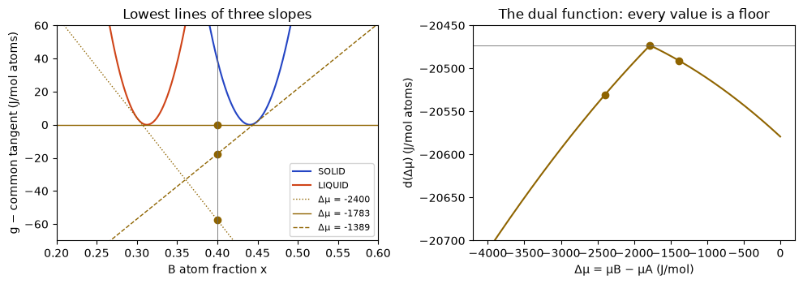

```python
def tangent(x):
    return mu_A_star + d_mu_star * np.asarray(x)        # the common tangent, used as zero

xs = np.linspace(0.2, 0.6, 801)
slopes = [-2400.0, d_mu_star, -1389.0]
fig, (left, right) = plt.subplots(1, 2, figsize=(10, 3.6))
for phase, model in lens.items():
    left.plot(xs, model.g(xs) - tangent(xs), color=COLOUR[phase], label=phase)
for s, ls in zip(slopes, (":", "-", "--")):
    value, touch = dual(lens, Z_LENS, s)
    left.plot(xs, value + s * (xs - Z_LENS) - tangent(xs), color=LINE_C, ls=ls, lw=1, label=f"Δμ = {s:.0f}")
    left.plot(Z_LENS, value - d_star, "o", color=LINE_C)
left.axvline(Z_LENS, color=DIP_C, lw=0.6)
left.set(xlim=(0.2, 0.6), ylim=(-70, 60), xlabel="B atom fraction x",
         ylabel="g − common tangent (J/mol atoms)", title="Lowest lines of three slopes")
left.legend(fontsize=8)
grid = np.linspace(-4000.0, 0.0, 401)
right.plot(grid, [dual(lens, Z_LENS, s)[0] for s in grid], color=LINE_C)
for s in slopes:
    right.plot(s, dual(lens, Z_LENS, s)[0], "o", color=LINE_C)
right.axhline(d_star, color=DIP_C, lw=0.6)
right.set(xlabel="Δμ = μB − μA (J/mol)", ylabel="d(Δμ) (J/mol atoms)", ylim=(-20700, -20450),
          title="The dual function: every value is a floor")
plt.tight_layout(); plt.show()
```

**Why the top sits at a kink.** Change $\Delta\mu$ a little and the touching state $x^*(\Delta\mu)$ stays put to first order, so the slope of $d$ is $z-x^*(\Delta\mu)$: how far the touching state is from the sample. When one SOLID state touches ($x^*>z$), $d$ falls as $\Delta\mu$ grows; when one LIQUID state touches ($x^*<z$), it rises. At the top both touch, the slope jumps from $z-x_L>0$ to $z-x_S<0$, and the lever rule is the statement that the amounts $f_L,f_S$ average these two slopes to zero.

```python
print(f"slopes on the two sides of the top: z - x_L = {Z_LENS - x_L:+.4f}, z - x_S = {Z_LENS - x_S:+.4f}")
print(f"lever-rule average f_L (z - x_L) + f_S (z - x_S) = {f_L * (Z_LENS - x_L) + f_S * (Z_LENS - x_S):.1e}")
grid_values = np.array([dual(lens, Z_LENS, s)[0] for s in grid])
assert np.all(grid_values <= d_star + 1e-9), "a value of d lies above the answer (weak duality broken)"
assert np.all(np.diff(grid_values, 2) <= 1e-6), "d is not concave on the grid"
print(f"all {grid.size} grid values lie at or below {d_star:.4f}, and d bends down")
```

```
slopes on the two sides of the top: z - x_L = +0.0876, z - x_S = -0.0405
lever-rule average f_L (z - x_L) + f_S (z - x_S) = 3.5e-18
all 401 grid values lie at or below -20473.1242, and d bends down
```

### Your turn: the value of $d$ at step 10's slope

Step 10's menu gave the line $\mu_A=-19873.9$, $\Delta\mu=-1389.0$ J/mol and the ceiling $-20429.54$. Use `dual` (or the formula of notebook f4d for the touching state) to find $d(-1389.0)$, to two decimals.

```python
d_menu = None    # J/mol atoms
check(d_menu, "f4g_dual_menu_slope")
```

```
f4g_dual_menu_slope: not attempted yet. Replace None with your value and run the cell again.
```

```python
#@title After your attempt: d at step 10's slope
value, touch = dual(lens, Z_LENS, -1389.0)
print(f"d(-1389.0) = {value:.2f} J/mol atoms; the lowest line of that slope touches {touch.phase} at x = {touch.x:.4f}")
if DEFAULTS:
    confirm(value, -20490.7222, "d at step 10's slope", tol=1e-3)
```

```
d(-1389.0) = -20490.72 J/mol atoms; the lowest line of that slope touches SOLID at x = 0.4489
✓ d at step 10's slope reproduces the lesson value.
```

## 2. Floors are dual values (main track, 10 min)

Step 14's floor was "the line at $z$, lowered by the deepest dip": $G_{\text{low}}=\mu_A^{(k)}+\Delta\mu^{(k)}z+\text{dip}_k$. The deepest dip is $\min_{p,x}[g_p(x)-\mu_A^{(k)}-\Delta\mu^{(k)}x]=\mu_A(\Delta\mu^{(k)})-\mu_A^{(k)}$, so $\mu_A^{(k)}$ cancels:

$$G_{\text{low}}^{(k)}=\mu_A(\Delta\mu^{(k)})+\Delta\mu^{(k)}z=d(\Delta\mu^{(k)}).$$

The floor is the dual function at the master's slope. The master's height $\mu_A^{(k)}$ does not matter for the floor; only its slope does. Since the master's line passes through the ceiling at $z$, the floor is also ceiling + deepest dip.

```python
print(" round   μA (J/mol)   Δμ (J/mol)    ceiling      deepest dip    floor (step 14)    d(Δμ)")
for it in history[:4]:
    m = it.master
    value, _ = dual(lens, Z_LENS, m.d_mu)
    if it.k == 2:      # round 2 is your turn below: only its slope is shown
        print(f"{it.k:5d}  {'':10s}  {m.d_mu:10.2f}  {'(your turn)':>11s}")
    else:
        print(f"{it.k:5d}  {m.mu_A:10.1f}  {m.d_mu:10.2f}  {m.G_up:11.2f}  {it.best.depth:12.4f}  {it.G_low_raw:15.4f}  {value:11.4f}")
    assert abs(it.G_low_raw - value) < 1e-8, f"round {it.k}: the floor is not d at the master's slope"
    assert abs(it.G_low_raw - (m.G_up + it.best.depth)) < 1e-8, f"round {it.k}: floor is not ceiling + dip"
if DEFAULTS:
    for it, up, dip in zip(history, (-20429.54, -20470.64, -20472.07, -20473.12), (-61.18, -3.99, -1.55, -0.0027)):
        confirm(it.master.G_up, up, f"Round {it.k} ceiling", tol=0.006)
        confirm(it.best.depth, dip, f"Round {it.k} deepest dip", tol=0.006)
```

```
 round   μA (J/mol)   Δμ (J/mol)    ceiling      deepest dip    floor (step 14)    d(Δμ)
    0    -19873.9    -1388.99    -20429.54      -61.1804      -20490.7229  -20490.7229
    1    -19750.7    -1799.95    -20470.64       -3.9931      -20474.6319  -20474.6319
    2                -1770.76  (your turn)
    3    -19760.0    -1782.78    -20473.12       -0.0027      -20473.1250  -20473.1250
✓ Round 0 ceiling reproduces the lesson value.
✓ Round 0 deepest dip reproduces the lesson value.
✓ Round 1 ceiling reproduces the lesson value.
✓ Round 1 deepest dip reproduces the lesson value.
✓ Round 2 ceiling reproduces the lesson value.
✓ Round 2 deepest dip reproduces the lesson value.
✓ Round 3 ceiling reproduces the lesson value.
✓ Round 3 deepest dip reproduces the lesson value.
```

### Your turn: the round-2 floor as a dual value

Round 2's master has the slope printed in the table, $\Delta\mu^{(2)}=-1770.76$ J/mol. Compute $d(\Delta\mu^{(2)})$ with `dual`, using the master's slope `history[2].master.d_mu`, to two decimals.

```python
floor_round2 = None   # J/mol atoms
check(floor_round2, "f4g_floor_round2")
```

```
f4g_floor_round2: not attempted yet. Replace None with your value and run the cell again.
```

```python
#@title After your attempt: round 2
value, touch = dual(lens, Z_LENS, history[2].master.d_mu)
print(f"d(Δμ2) = {value:.4f} J/mol atoms (touches {touch.phase} at {touch.x:.4f}); step 14's floor {history[2].G_low_raw:.4f}")
if DEFAULTS:
    confirm(value, -20473.6125, "The round-2 floor", tol=1e-3)
```

```
d(Δμ2) = -20473.6125 J/mol atoms (touches SOLID at 0.4408); step 14's floor -20473.6125
✓ The round-2 floor reproduces the lesson value.
```

## 3. Column generation is a cutting-plane method (main track, 15 min)

Each state $j$ on the menu gives one straight line in $\Delta\mu$, a *cut*:

$$c_j(\Delta\mu)=g_j+\Delta\mu\,(z-x_j)\ \ge\ d(\Delta\mu)\quad\text{for every }\Delta\mu .$$

The lowest of the menu's cuts, $m(\Delta\mu)=\min_j c_j(\Delta\mu)$, is a piecewise-straight *model* of $d$ from above. Maximising it is a small LP in $(\mu_A,\Delta\mu)$: make $\mu_A+\Delta\mu\,z$ as large as possible while $\mu_A+\Delta\mu\,x_j\le g_j$ for every menu state. That is the dual of the master, so its maximum is the ceiling and its maximiser is the master's slope.

Then pricing at that slope finds the touching state $x^*$, whose cut touches $d$ exactly there; adding $x^*$ to the menu adds that cut, and the model gets lower where it was too high. This loop (maximise a cutting-plane model, evaluate the function and its slope there, add the new cut) is *Kelley's cutting-plane method* (Kelley 1960). Column generation on the master is Kelley's method on $d$, written from the other side.

The next cell solves the model's LP directly, without the master's multipliers, and compares.

```python
def kelley_step(states, z, lo=None, hi=None):
    """Maximise the cut model min_j [g_j + Δμ (z - x_j)], with Δμ kept in [lo, hi] if given.

    Variables (μA, Δμ): maximise μA + Δμ z subject to μA + Δμ x_j <= g_j.
    Returns (Δμ, model value).
    """
    A = [[1.0, s.x] for s in states]
    b = [s.g for s in states]
    r = linprog([-1.0, -z], A_ub=A, b_ub=b, bounds=[(None, None), (lo, hi)], method="highs-ds")
    return float(r.x[1]), -float(r.fun)

print(" round   model maximiser   master's Δμ     model maximum    ceiling")
for it in history[:4]:
    s_k, top = kelley_step(it.master.states, Z_LENS)
    print(f"{it.k:5d}  {s_k:15.4f}  {it.master.d_mu:12.4f}  {top:15.4f}  {it.master.G_up:11.4f}")
    assert abs(s_k - it.master.d_mu) < 1e-6 and abs(top - it.master.G_up) < 1e-6, f"round {it.k}: model and master differ"
    new = it.best                                  # the state pricing adds after this round
    cut_at_k = float(lens[new.phase].g(new.x)) + it.master.d_mu * (Z_LENS - new.x)
    assert abs(cut_at_k - it.G_low_raw) < 1e-8, "the new cut does not touch d at the master's slope"
print("the model's maximiser is the master's slope, its maximum the ceiling; each new cut touches d there")
```

```
 round   model maximiser   master's Δμ     model maximum    ceiling
    0       -1388.9870    -1388.9870      -20429.5424  -20429.5424
    1       -1799.9503    -1799.9503      -20470.6388  -20470.6388
    2       -1770.7563    -1770.7563      -20472.0655  -20472.0655
    3       -1782.7781    -1782.7781      -20473.1223  -20473.1223
the model's maximiser is the master's slope, its maximum the ceiling; each new cut touches d there
```

The picture: $d$ (solid) and the cut model of rounds 0–3 (dashed). Each round adds one cut and the model drops onto $d$ near its top. The dots are the ceilings (model maxima); the crosses directly below them are the floors $d(\Delta\mu^{(k)})$.

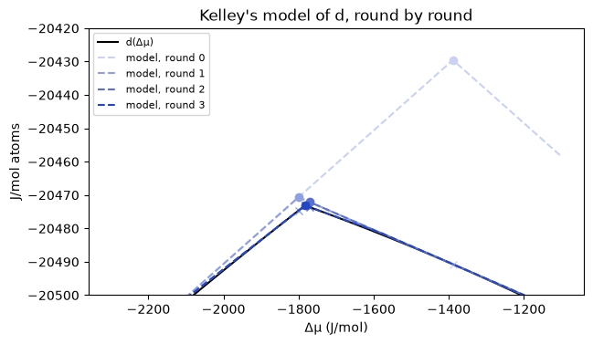

```python
grid3 = np.linspace(-2300.0, -1100.0, 241)
fig, ax = plt.subplots(figsize=(7, 3.8))
ax.plot(grid3, [dual(lens, Z_LENS, s)[0] for s in grid3], color="black", lw=1.5, label="d(Δμ)")
for it, shade in zip(history[:4], ("#c9d2f2", "#8fa0e0", "#5a6fcf", SOLID_C)):
    states = it.master.states
    model_vals = [min(st.g + s * (Z_LENS - st.x) for st in states) for s in grid3]
    ax.plot(grid3, model_vals, ls="--", color=shade, label=f"model, round {it.k}")
    ax.plot(it.master.d_mu, it.master.G_up, "o", color=shade)
    ax.plot(it.master.d_mu, it.G_low_raw, "x", color=shade)
ax.set(xlabel="Δμ (J/mol)", ylabel="J/mol atoms", ylim=(-20500, -20420), title="Kelley's model of d, round by round")
ax.legend(fontsize=8); plt.show()
```

**The duality gap of the one-state problem.** Take the harder-looking problem "the sample stays one homogeneous state": choose one phase model $p$ and $x=z$, at the lowest $g_p(z)$. Pricing the rule $x=z$ with $\Delta\mu$ gives exactly the same $d(\Delta\mu)$ as above. But now the best single state is higher than the top of $d$: the difference is the *duality gap* (not step 14's remaining uncertainty, which is ceiling minus floor of one run), and here it has a physical name, the energy gained by splitting into two phases. A Lagrangian dual cannot see whether a mixture is allowed; it always answers for the mixture problem (its convex envelope).

For SOLID alone the curve is convex (ideal mixing bends up everywhere), so its own dual has no gap: the best line of slope $g_S'(z)$ touches at $z$.

A single phase model with a hump does have a gap of its own: the regular solution of step 15 at $z=0.15$. Its curve at $0.15$ lies above the common tangent of 0.070 and 0.930 (the coexisting compositions of `binary_family`).

```python
from course.foundations import binary_family as bf
alpha = d.regular_models(T_REG)["ALPHA"]
x_a, x_b = bf.regular_binodal(T_REG)["compositions"]
G_reg = float(alpha.g(x_a)) + (Z_REG - x_a) / (x_b - x_a) * float(alpha.g(x_b) - alpha.g(x_a))
print(f"g(0.15) = {float(alpha.g(Z_REG)):.2f}, convex envelope {G_reg:.4f}, gap {float(alpha.g(Z_REG)) - G_reg:.2f} J/mol atoms")
```

```
g(0.15) = -5461.69, convex envelope -5585.1051, gap 123.41 J/mol atoms
```

### Your turn: the duality gap at 0.40

For the lens at $z=0.40$, what is the duality gap of the one-state problem: the best single homogeneous state minus the top of $d$?

```python
gap_one_state = None   # J/mol atoms, positive
check(gap_one_state, "f4g_onestate_gap")
```

```
f4g_onestate_gap: not attempted yet. Replace None with your value and run the cell again.
```

```python
#@title After your attempt: the duality gap
g_S, g_L = float(lens["SOLID"].g(Z_LENS)), float(lens["LIQUID"].g(Z_LENS))
one_state = min(g_S, g_L)
print(f"one homogeneous state at z: SOLID {g_S:.4f}, LIQUID {g_L:.4f}  ->  best {one_state:.4f} J/mol atoms")
print(f"top of d {d_star:.4f}  ->  duality gap (phase-separation gain) {one_state - d_star:.4f} J/mol atoms")
solid_only = {"SOLID": lens["SOLID"]}
own = dual(solid_only, Z_LENS, float(lens["SOLID"].slope(Z_LENS)))[0]
print(f"SOLID alone: g_S(z) = {g_S:.4f}, its dual at the tangent slope {own:.4f}, gap {g_S - own:.1e}")
assert abs(g_S - own) < 1e-8, "SOLID alone should have no duality gap"
if DEFAULTS:
    confirm(g_S - d_star, 39.0665, "The one-state duality gap at 0.40", tol=1e-3)
```

```
one homogeneous state at z: SOLID -20434.0577, LIQUID -20274.0577  ->  best -20434.0577 J/mol atoms
top of d -20473.1242  ->  duality gap (phase-separation gain) 39.0665 J/mol atoms
SOLID alone: g_S(z) = -20434.0577, its dual at the tangent slope -20434.0577, gap -3.6e-12
✓ The one-state duality gap at 0.40 reproduces the lesson value.
```

## 4. Why the floor wobbles, and a box step (dive deeper, 20 min)

Kelley's method jumps to the top of the current model. Where the model has few cuts, its top can be far from the top of $d$, or not unique at all. Then the next slope is far off, and the raw floor $d(\Delta\mu^{(k)})$ can fall even though the ceiling never rises. Notebook f4d showed this for the lens started from the two pure ends; the slopes tell why. (Round counts here stop at a remaining uncertainty of `TOL`; f4d runs that start to 1e-9, so it counts more rounds.)

```python
from_ends = d.column_generation(lens, d.menu_states(lens, [0.0, 1.0]), Z_LENS, tol=TOL, max_iter=40)
for it in from_ends:
    print(f"round {it.k}: Δμ {it.master.d_mu:9.1f}   raw floor {it.G_low_raw:10.2f}   ceiling {it.master.G_up:10.2f}")
```

```
round 0: Δμ    3400.0   raw floor  -20970.19   ceiling  -14040.00
round 1: Δμ   -9169.2   raw floor  -21579.95   ceiling  -19067.67
round 2: Δμ   -2136.7   raw floor  -20505.28   ceiling  -20132.13
round 3: Δμ    -616.4   raw floor  -20534.83   ceiling  -20362.24
round 4: Δμ   -1699.0   raw floor  -20476.59   ceiling  -20464.10
round 5: Δμ   -1790.6   raw floor  -20473.81   ceiling  -20472.72
round 6: Δμ   -1782.2   raw floor  -20473.15   ceiling  -20473.07
round 7: Δμ   -1782.8   raw floor  -20473.12   ceiling  -20473.12
```

The slope swings from $+3400$ to $-9169$ and back before it settles near $-1783$; each swing to a far slope gives a low raw floor.

**The regular solution of steps 15–17.** The course's local–global rounds start from the single state at $z=0.15$. Round 0 uses the tangent at 0.15 (chosen by hand, as on step 15). After the state near 0.958 is added, the menu still has nothing left of 0.15, so the only mixture is the 0.15 state itself, and every slope up to that of the line through both dots is an equally good top of the model: the master is degenerate. The solver returns the flat line, $\Delta\mu=0$.

```python
reg = {"ALPHA": alpha}
d_mu_t = float(alpha.slope(Z_REG)); g_z = float(alpha.g(Z_REG)); mu_A_t = g_z - d_mu_t * Z_REG
seed = [d.State("ALPHA", Z_REG, g_z)]
plain = d.column_generation(reg, seed, Z_REG, tol=TOL, max_iter=40,
                            line=lambda master, k: (mu_A_t, d_mu_t) if k == 0 else (master.mu_A, master.d_mu))
for it in plain:
    print(f"round {it.k}: Δμ {it.master.d_mu + 0.0:9.1f}   deepest dip {it.best.depth:10.4f} at {it.best.x:.4f}"
          f"   raw floor {it.G_low_raw:9.2f}   ceiling {it.master.G_up:9.2f}   remaining {it.gap:.2e}")
two = plain[1].master.states
slope_two = (two[1].g - two[0].g) / (two[1].x - two[0].x)
flat = [min(st.g + s * (Z_REG - st.x) for st in two) for s in (0.0, slope_two / 2, slope_two)]
print(f"round 1 model top: {flat[0]:.2f} at Δμ = 0, {flat[1]:.2f} at {slope_two / 2:.0f}, {flat[2]:.2f} at {slope_two:.0f}: flat")
if DEFAULTS:
    confirm(plain[1].master.d_mu, 0.0, "Round 1 slope (the flat line)", tol=1e-9)
    confirm(plain[1].best.depth, -1593.6, "Round 1 deepest dip", tol=0.05)
    confirm(plain[1].best.x, 0.0085, "Where it lies", tol=5e-5)
```

```
round 0: Δμ   14462.1   deepest dip -2082.0233 at 0.9579   raw floor  -7543.72   ceiling  -5461.69   remaining 2.08e+03
round 1: Δμ       0.0   deepest dip -1593.6093 at 0.0085   raw floor  -7055.30   ceiling  -5461.69   remaining 1.59e+03
round 2: Δμ   11261.8   deepest dip  -186.4490 at 0.0595   raw floor  -5648.14   ceiling  -5461.69   remaining 1.86e+02
round 3: Δμ   12029.7   deepest dip   -29.5998 at 0.9304   raw floor  -5608.28   ceiling  -5578.68   remaining 2.96e+01
round 4: Δμ   11995.7   deepest dip    -3.6942 at 0.0700   raw floor  -5585.45   ceiling  -5581.75   remaining 3.69e+00
round 5: Δμ   12000.0   deepest dip    -0.0071 at 0.9299   raw floor  -5585.11   ceiling  -5585.10   remaining 7.06e-03
round 6: Δμ   12000.0   deepest dip    -0.0001 at 0.0701   raw floor  -5585.11   ceiling  -5585.10   remaining 1.48e-04
round 1 model top: -5461.69 at Δμ = 0, -5461.69 at 5942, -5461.69 at 11885: flat
✓ Round 1 slope (the flat line) reproduces the lesson value.
✓ Round 1 deepest dip reproduces the lesson value.
✓ Where it lies reproduces the lesson value.
```

On this problem the raw floor happens not to fall, but the slope of round 1 is a whole $12000$ J/mol away from the answer: the common tangent of the regular solution has slope $\Delta\mu=12000$ J/mol at 800 K, the rise of its end line, because the rest of the model is symmetric about $x=0.5$.

```python
print(f"slope of the common tangent: {float(alpha.slope(x_a)):.4f} J/mol at x = {x_a:.4f} and"
      f" {float(alpha.slope(x_b)):.4f} at x = {x_b:.4f}; end-line rise b = {alpha.b:.0f} J/mol")
```

```
slope of the common tangent: 12000.0000 J/mol at x = 0.0701 and 12000.0000 at x = 0.9299; end-line rise b = 12000 J/mol
```

**A box step.** The classic remedy is stabilisation: keep the next slope near a trusted one. We implement this simple variant of the box step of Marsten, Hogan and Blankenship (1975):

1. keep a centre $\Delta\mu_c$: the slope with the highest dual value $d$ so far (round 0: the tangent at 0.15, as in the plain run);
2. each round, maximise the cut model only over $[\Delta\mu_c-\delta,\ \Delta\mu_c+\delta]$ (`kelley_step` with bounds), with $\delta$ = `BOX`;
3. price at that slope with the same full-scan pricer as the plain run, and add the touching state;
4. move the centre there if its $d$ is higher than the centre's;
5. the ceiling is always the unboxed master's best mixture (`solve_master`), the floor the best $d$ so far; stop when ceiling minus floor is at most `TOL`.

The box does not change what is proved: every $d$ is a floor and every ceiling a real mixture, whatever slopes are tried.

```python
def box_step(models, seed, z, first_slope, delta, tol=TOL, max_rounds=80):
    """Box-stabilised column generation; returns one row per round."""
    states, centre, best, rows = list(seed), first_slope, -math.inf, []
    for k in range(max_rounds):
        slope = first_slope if k == 0 else kelley_step(states, z, centre - delta, centre + delta)[0]
        value, touch = dual(models, z, slope)         # exact pricing at the chosen slope
        if value > best:
            best, centre = value, slope
        ceiling = d.solve_master(states, z).G_up
        rows.append({"k": k, "slope": slope, "d": value, "ceiling": ceiling, "remaining": ceiling - best})
        if ceiling - best <= tol:
            break
        states.append(d.State(touch.phase, touch.x, float(models[touch.phase].g(touch.x))))
    return rows

boxed = box_step(reg, seed, Z_REG, d_mu_t, BOX)
for r in boxed:
    print(f"round {r['k']}: Δμ {r['slope']:9.1f}   d {r['d']:9.2f}   ceiling {r['ceiling']:9.2f}   remaining {r['remaining']:.2e}")
print(f"rounds to remaining <= {TOL} J/mol atoms: plain {plain[-1].k}, box step (δ = {BOX:.0f} J/mol) {boxed[-1]['k']}")
```

```
round 0: Δμ   14462.1   d  -7543.72   ceiling  -5461.69   remaining 2.08e+03
round 1: Δμ   13462.1   d  -6740.22   ceiling  -5461.69   remaining 1.28e+03
round 2: Δμ   12462.1   d  -5947.16   ceiling  -5461.69   remaining 4.85e+02
round 3: Δμ   11845.1   d  -5597.67   ceiling  -5461.69   remaining 1.36e+02
round 4: Δμ   12001.6   d  -5586.33   ceiling  -5584.79   remaining 1.54e+00
round 5: Δμ   11999.8   d  -5585.12   ceiling  -5584.94   remaining 1.86e-01
round 6: Δμ   12000.0   d  -5585.11   ceiling  -5585.11   remaining 1.99e-05
rounds to remaining <= 0.001 J/mol atoms: plain 6, box step (δ = 1000 J/mol) 6
```

Before reading the comparison, **predict**: does a narrower box help or hurt here? The next cell runs several box widths.

```python
widths = [250.0, 500.0, 1000.0, 2000.0, 5000.0]
counts = {w: box_step(reg, seed, Z_REG, d_mu_t, w)[-1]["k"] for w in widths}
print("rounds, plain column generation:", plain[-1].k)
for w, n in counts.items():
    print(f"rounds, box step δ = {w:6.0f} J/mol: {n}")
if DEFAULTS:
    confirm(plain[-1].k, 6, "Rounds of the plain run", tol=0)
    confirm(boxed[-1]["k"], 6, "Rounds of the box step with δ = 1000 J/mol", tol=0)
```

```
rounds, plain column generation: 6
rounds, box step δ =    250 J/mol: 13
rounds, box step δ =    500 J/mol: 8
rounds, box step δ =   1000 J/mol: 6
rounds, box step δ =   2000 J/mol: 5
rounds, box step δ =   5000 J/mol: 5
✓ Rounds of the plain run reproduces the lesson value.
✓ Rounds of the box step with δ = 1000 J/mol reproduces the lesson value.
```

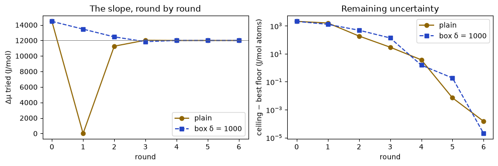

```python
fig, (a1, a2) = plt.subplots(1, 2, figsize=(10, 3.4))
a1.plot([it.k for it in plain], [it.master.d_mu for it in plain], "o-", color=LINE_C, label="plain")
a1.plot([r["k"] for r in boxed], [r["slope"] for r in boxed], "s--", color=SOLID_C, label=f"box δ = {BOX:.0f}")
a1.axhline(12000.0, color=DIP_C, lw=0.6)
a1.set(xlabel="round", ylabel="Δμ tried (J/mol)", title="The slope, round by round"); a1.legend()
a2.semilogy([it.k for it in plain], [it.gap for it in plain], "o-", color=LINE_C, label="plain")
a2.semilogy([r["k"] for r in boxed], [r["remaining"] for r in boxed], "s--", color=SOLID_C, label=f"box δ = {BOX:.0f}")
a2.set(xlabel="round", ylabel="ceiling − best floor (J/mol atoms)", title="Remaining uncertainty"); a2.legend()
plt.tight_layout(); plt.show()
```

**What this shows, honestly.** The box removes the jump to $\Delta\mu=0$: its slopes walk from 14462 towards 12000 in steps of at most $\delta$. But the plain run needs only six rounds, and the box step with $\delta=1000$ J/mol needs six as well. A narrow box (250 or 500 J/mol) costs more rounds, because the slope has to walk the whole way from the tangent at 0.15; wider boxes save at most one round here. The box's own model also has flat tops, and which point of a flat top the LP solver returns can change a count by one. No width is best in advance, and on this problem stabilisation does not pay off clearly.

The reason is the size of the problem. The dual has one variable, the pricing is exact, and two or three good cuts already pin the top of a concave function of one variable. Stabilisation pays off where the dual has many variables (many elements, many rows), the master is degenerate round after round, and pricing is expensive: there Kelley's jumps cause long tails. Our problems are too small to show that.

## 5. Exercises (both tracks, 20 min)

**Exercise 1 (main).** The Lagrangian bound for a given slope: give $d(-2000)$ for the lens at $z=0.40$, to two decimals. Use the closed form for the touching state of each phase, $x^*=1/(1+e^{-(\Delta\mu-b)/RT})$ with $b$ the rise of each model's end line (`lens[p].b`), or `dual`.

```python
bound_2000 = None   # J/mol atoms
check(bound_2000, "f4g_bound_slope_2000")
```

```
f4g_bound_slope_2000: not attempted yet. Replace None with your value and run the cell again.
```

**Exercise 2 (main).** The slope of $d$ at $\Delta\mu=-1389.0$ is $z-x^*$, with $x^*$ the touching state. Give it to four decimals. Does $d$ rise or fall if $\Delta\mu$ is made a little larger?

```python
slope_of_d = None   # (B atom fraction, no unit)
check(slope_of_d, "f4g_slope_of_d")
```

```
f4g_slope_of_d: not attempted yet. Replace None with your value and run the cell again.
```

**Exercise 3 (main).** Run the box step of section 4 on the regular solution with $\delta=750$ J/mol (`box_step(reg, seed, Z_REG, d_mu_t, 750.0)`). How many rounds does it need until ceiling minus best floor is at most `TOL`? Is that more or fewer than the plain run?

```python
box750_rounds = None   # a whole number
check(box750_rounds, "f4g_box750_rounds")
```

```
f4g_box750_rounds: not attempted yet. Replace None with your value and run the cell again.
```

```python
#@title After your attempt: exercises 1–3
RT = d.R * T_LENS
for p, model in lens.items():
    x_star = 1 / (1 + math.exp(-(-2000.0 - model.b) / RT))
    print(f"{p:6s}: touching state x* = {x_star:.4f}, g - Δμ x = {float(model.g(x_star)) + 2000.0 * x_star:.2f}")
value, touch = dual(lens, Z_LENS, -2000.0)
print(f"d(-2000) = {value:.2f} J/mol atoms (the lower of the two, plus Δμ z)")
_, touch_menu = dual(lens, Z_LENS, -1389.0)
print(f"slope of d at -1389.0: z - x* = {Z_LENS - touch_menu.x:.4f} (negative: d falls as Δμ grows)")
numeric = (dual(lens, Z_LENS, -1389.0 + 1e-3)[0] - dual(lens, Z_LENS, -1389.0 - 1e-3)[0]) / 2e-3
box750 = box_step(reg, seed, Z_REG, d_mu_t, 750.0)[-1]["k"]
print(f"numerical slope {numeric:.4f};  box step δ = 750 J/mol: {box750} rounds (plain: {plain[-1].k})")
if DEFAULTS:
    confirm(box750, 7, "Rounds of the box step with δ = 750 J/mol", tol=0)
    confirm(value, -20492.5859, "d(-2000)", tol=1e-3)
    confirm(Z_LENS - touch_menu.x, -0.04887, "The slope of d at step 10's slope", tol=1e-5)
assert abs(numeric - (Z_LENS - touch_menu.x)) < 1e-5, "the slope of d is not z - x*"
```

```
SOLID : touching state x* = 0.4359, g - Δμ x = -19664.82
LIQUID: touching state x* = 0.3084, g - Δμ x = -19692.59
d(-2000) = -20492.59 J/mol atoms (the lower of the two, plus Δμ z)
slope of d at -1389.0: z - x* = -0.0489 (negative: d falls as Δμ grows)
numerical slope -0.0489;  box step δ = 750 J/mol: 7 rounds (plain: 6)
✓ Rounds of the box step with δ = 750 J/mol reproduces the lesson value.
✓ d(-2000) reproduces the lesson value.
✓ The slope of d at step 10's slope reproduces the lesson value.
```

**Exercise 4 (dive deeper).** Run `box_step` on the lens started from the two pure ends (`d.menu_states(lens, [0.0, 1.0])`, first slope from its master, $\Delta\mu=3400$) with $\delta=1000$ J/mol. Compare the rounds with the plain run of section 4 (`from_ends`), and look at the slopes tried.

**Exercise 5 (dive deeper).** Implement Wentges smoothing (Wentges 1997) instead of the box: price at $\alpha\,\Delta\mu_c+(1-\alpha)\,\Delta\mu^{(k)}$ with $\alpha=0.5$, where $\Delta\mu^{(k)}$ is the master's slope and $\Delta\mu_c$ the centre as above. On the regular solution, count the rounds to `TOL`.

```python
#@title After your attempt: exercises 4 and 5
ends = d.menu_states(lens, [0.0, 1.0])
lens_box = box_step(lens, ends, Z_LENS, d.solve_master(ends, Z_LENS).d_mu, 1000.0)
print(f"lens from the pure ends: plain {from_ends[-1].k} rounds, box δ = 1000: {lens_box[-1]['k']} rounds")
print("box slopes:", [round(r["slope"]) for r in lens_box])

def wentges(models, seed, z, first_slope, a, tol=TOL, max_rounds=80):
    states, centre, best = list(seed), first_slope, -math.inf
    for k in range(max_rounds):
        master = d.solve_master(states, z)
        slope = first_slope if k == 0 else a * centre + (1 - a) * master.d_mu
        value, touch = dual(models, z, slope)
        if value > best:
            best, centre = value, slope
        if master.G_up - best <= tol:
            return k
        if all(abs(s.x - touch.x) > 1e-12 for s in states):   # a repeated state adds nothing
            states.append(d.State(touch.phase, touch.x, float(models[touch.phase].g(touch.x))))
    return None

print(f"regular solution: plain {plain[-1].k} rounds, Wentges α = 0.5: {wentges(reg, seed, Z_REG, d_mu_t, 0.5)} rounds")
```

```
lens from the pure ends: plain 7 rounds, box δ = 1000: 10 rounds
box slopes: [3400, 2400, 1400, 400, -600, -1600, -2600, -1822, -1780, -1783, -1783]
regular solution: plain 6 rounds, Wentges α = 0.5: 18 rounds
```

*After your attempt.* From the pure ends the box walks from $+3400$ down in steps of 1000 J/mol and needs more rounds than the plain run, whose wild swings happen to land useful cuts. With a fixed $\alpha=0.5$ every round prices halfway between the centre and the master's slope, never at the master's slope itself; near the end the centre moves only when the halfway slope beats it, so the remaining uncertainty shrinks by about half per round and the last digits come slowly. Practical codes change $\alpha$ as they go. Neither result says stabilisation is useless, only that these one-variable problems do not need it.

## 6. Limits

- One composition variable: the dual has a single slope $\Delta\mu$ (plus the height $\mu_A$, which drops out). With more elements the dual has more variables, the model of $d$ more facets, and the picture of section 3 does not carry over directly.
- Exact pricing is available here: a formula for the ideal lens and a full scan of one variable for the regular solution. Where pricing is only approximate, a "floor" is a floor only if the deepest dip is truly found.
- Teaching scale: two invented models, a handful of rounds. The round counts of section 4 are for these problems only and say nothing about solver speed in general.
- Floating point: all comparisons use small tolerances; nothing here is a rigorous numerical certificate.

## Recap

- $d(\Delta\mu)$ is the height at $z$ of the lowest line of slope $\Delta\mu$; it is concave, every value is a floor, and its top is the equilibrium energy (−20473.1242 J/mol atoms at $\Delta\mu=-1782.77$ J/mol for the lens).
- Step 14's floor in every round is $d$ at the master's slope.
- Column generation is Kelley's cutting-plane method on $d$: the master's dual maximises the cut model, the ceiling is its maximum, pricing adds the cut that touches $d$.
- The one-state problem has a duality gap: the phase-separation gain, 39.07 J/mol atoms for the lens at 0.40.
- A box step keeps the slopes calm; on these one-variable problems it does not clearly save rounds.

**On the website:** steps 13 (find a missing state), 14 (ceiling, floor and the remaining uncertainty) and 15 (local search can miss a valley).